# GAISE for Majors

JSM 2020

## Some Background

- Calvin University:
  - Liberal arts university with ~3500 undergraduate students
  - Large core curriculum, small majors (Statistics = ~ 36 + 10 hours)
- Prob/Stats sequence
  - Prob/Stats taken by students from many programs
  - Some of these students have not had statistics before
- The first time I taught our prob/stat sequence (in 2005)
  - Just under half of students took the second course
  - Most were more interested in statistics than in probability
  - But the course I inherited was basically all probability in the first semester
  - GAISE was brand new and change was afoot (Cobb’s *Ptolameic Curriculum*, etc.)

## What is GAISE?

Guidelines for Assessment and Instruction in Statistics Education

- PreK-12 Report
  - 2005/2007
- College Report
  - focused on Intro Stats courses
  - original in 2005
  - revised 2016
- available from ASA at https://www.amstat.org/asa/education/Guidelines-for-Assessment-and-Instruction-in-Statistics-Education-Reports.aspx

## GAISE College – 6 Recommendations

1. Teach statistical thinking.
   - Teach statistics as an investigative process of problem-solving and decision making.
   - Give students experience with multivariable thinking.
2. Focus on conceptual understanding.
3. Integrate real data with a context and purpose.
4. Foster active learning.
5. Use technology to explore concepts and analyze data.
6. Use assessments to improve and evaluate student learning.

## GAISE College – 6 Recommendations

1. Teach **statistical thinking**.
   - Teach statistics as an **investigative process** of problem-solving and decision making.
   - Give students experience with **multivariable** thinking.
2. Focus on **conceptual understanding**.
3. Integrate **real data** with a **context** and **purpose**.
4. Foster **active learning**.
5. Use **technology** to explore concepts and analyze data.
6. Use **assessments** to improve and evaluate student learning.

## GAISE College – 6 Recommendations

1. Teach statistical thinking (investigative, multivariable)
2. Focus on **conceptual understanding**.
   - **Michael Lavine** (10:45): “Likelihood … is the main *statistical concept* we should teach”
3. Integrate real data with a context and purpose.
4. Foster **active learning**.
   - **Erin E Blankenship** (11:25): *Active Learning, Not Just for Intro Stats*
5. Use technology to explore concepts and analyze data.
6. Use **assessments** to improve and evaluate student learning.
   - **Jennifer Green** (11:05): *Learning Through Assessment*

## GAISE College – 9 Goals

1. Students should become **critical consumers** of statistically-based results reported in popular media, recognizing whether reported results reasonably follow from the study and analysis conducted.
2. Students should be able to **recognize** questions for which the investigative process in **statistics would be useful** and should be able to answer questions using the investigative process.
3. Students should be able to produce **graphical displays and numerical summaries** and interpret what graphs do and do not reveal.
4. Students should recognize and be able to explain the **central role of variability** in the field of statistics.

## GAISE College – 9 Goals

5. Students should recognize and be able to explain the **central role of randomness** in designing studies and drawing conclusions.
   - **Dennis Sun** (10:25): “interleave probability and statistical inference topics”
6. Students should gain experience with how **statistical models**, including multivariable models, are used.
   - **Michael Lavine** (10:45): “Likelihood is the primary way to quantify the quality of a probability model.”
7. Students should demonstrate an understanding of, and ability to use, basic ideas of **statistical inference**, both hypothesis tests and interval estimation, in a variety of settings.
8. Students should be able to interpret and draw conclusions from **standard output from statistical software packages**.
9. Students should demonstrate an awareness of **ethical issues** associated with sound statistical practice.

## Outline of Panel

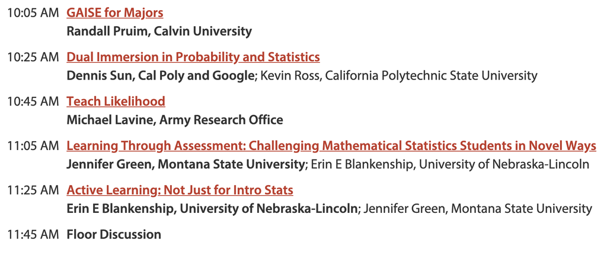

Post questions/comments in the session chat as we go along.

## First Adjustment: Statistics Early

- See basics of inference in first semester (tests, intervals, power, simulation-based methods)
- Lead with Lady Tasting Tea (or similar) on Day 1.

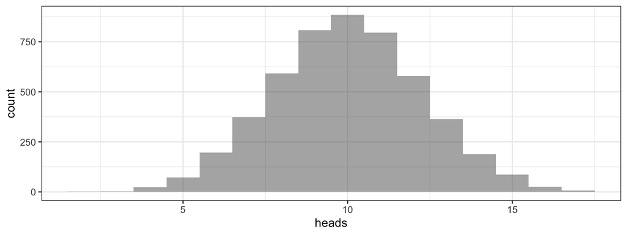

```r
Sims <- do(5000) * rflip(20)
Sims %>% gf_histogram(~ heads, binwidth = 1)
```

## Probability For Statistics

Probability then Statistics \(\rightarrow\) **Probability FOR Statistics**

- Use statistical ideas to motivate learning probability.
- Lady Tasting Tea \(\rightarrow\) Binomial distributions \(\rightarrow\) Binomial Test \(\rightarrow\) Normal approximation to Binomial Test
- Golfballs in the Yard \(\to\) Test Stats & Null Distributions
- How many replicates do I need to estimate a p-value empirically?
- Robustness: Is the coverage rate in my simulation consistent with nominal value?

More about this in the next talk (*Dual Immersion in Probability and Statistics*, Dennis Sun)

## Technology

These days the use of technology in a statistics class is not so controversial.

- Allows us to use larger, more interesting data sets
- Allows us to focus attention on the right parts of the task
- Allows us to teach reproducible analysis methods (eg, RMarkdown, scripting)

R/RStudio is a popular choice

- Free
- Toolkit get better rapidly (RStudio, tidyverse, publishing tools, etc.)

## Technology: You Gotta Have Style

But just using a statistical package like R/RStudio is not enough – it needs to be used well.

- Teach R as a language, but not a “programming” language
  - Much can be done with simple declarative commands, perhps chained with `%>%`.
  - Focus on communicating to R what you want to happen (what do you want R to do? what must it know to do that?)
  - Learning to write simple functions is a big power boost (and not that hard).
- Be professional about how you use technology
  - Adopt a set of complementary tools and a consistent style
  - Equivalent to using correct terminology and good notation
  - Instructors should know more than they teach

## Stat 344: First Exam Problem

**Problem 1** `<Details omitted>`

1. What is the maximum likelihood estimate for \(\theta\)?
2. If we test the null hypothesis that \(\theta = 2.5\), what is the p-value?
3. What is the 95% likelihood confidence interval for \(\theta\)?

## Stat 344: First Exam Problem – Preamble

Below is a graph of a log likelihood function \(l(\theta)\) for a data set with \(n = 23\).

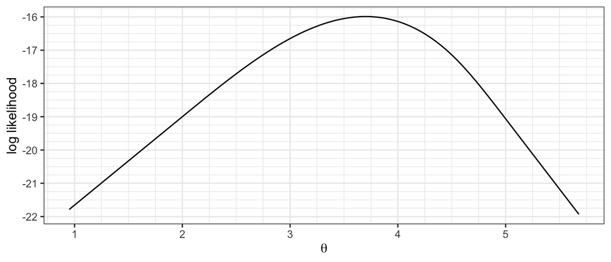

Using the information provided, answer the following questions as accurately as you can.

1. What is the maximum likelihood estimate for \(\theta\)?
2. If we test the null hypothesis that \(\theta = 2.5\), what is the p-value?
3. What is the 95% likelihood confidence interval for \(\theta\)?

## Visualizing Likelihood

`maxLik` + `fastR2` make it easy to visualize likelihood (for one parameter).

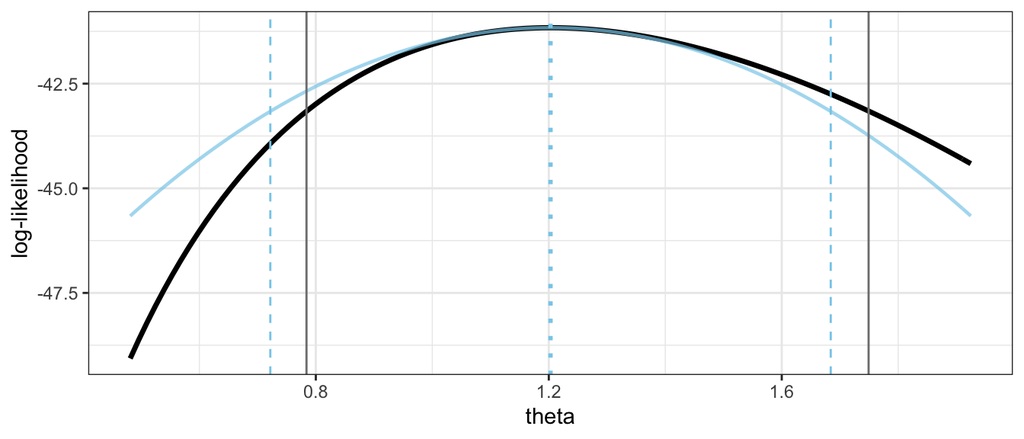

## Poisson and Exponential

Take advantage of the connection between the two distributions to help students shake a common misunderstanding of the Poisson rate parameter \(\lambda\).